# P6 - Analyse des ventes de la librairie Lapage

```python
cd /Users/ahami/Desktop/Formation_OCR/P6_Analyses_vente_librairie_avec_R_ou_Python/data
```

```
C:\Users\ahami\Desktop\Formation_OCR\P6_Analyses_vente_librairie_avec_R_ou_Python\data
```

```python
#Importation des librairies
import pandas as pd
import matplotlib.pyplot as plt
import numpy as np
import seaborn as sns

#Importation des tables
customers = pd.read_csv('customers.csv')
products = pd.read_csv('products.csv')
transactions = pd.read_csv('transactions.csv')

#Visualisation
display(customers.head(5))
display(products.head(5))
display(transactions.head(5))
```

|  | client_id | sex | birth |
| --- | --- | --- | --- |
| 0 | c_4410 | f | 1967 |
| 1 | c_7839 | f | 1975 |
| 2 | c_1699 | f | 1984 |
| 3 | c_5961 | f | 1962 |
| 4 | c_5320 | m | 1943 |

|  | id_prod | price | categ |
| --- | --- | --- | --- |
| 0 | 0_1421 | 19.99 | 0 |
| 1 | 0_1368 | 5.13 | 0 |
| 2 | 0_731 | 17.99 | 0 |
| 3 | 1_587 | 4.99 | 1 |
| 4 | 0_1507 | 3.99 | 0 |

|  | id_prod | date | session_id | client_id |
| --- | --- | --- | --- | --- |
| 0 | 0_1518 | 2022-05-20 13:21:29.043970 | s_211425 | c_103 |
| 1 | 1_251 | 2022-02-02 07:55:19.149409 | s_158752 | c_8534 |
| 2 | 0_1277 | 2022-06-18 15:44:33.155329 | s_225667 | c_6714 |
| 3 | 2_209 | 2021-06-24 04:19:29.835891 | s_52962 | c_6941 |
| 4 | 0_1509 | 2023-01-11 08:22:08.194479 | s_325227 | c_4232 |

# 1. Nettoyage

```python
#Vérification valeurs nulles
customers.info()
products.info()
transactions.info()
```

```
<class 'pandas.core.frame.DataFrame'>
RangeIndex: 8623 entries, 0 to 8622
Data columns (total 3 columns):
 #   Column     Non-Null Count  Dtype
---  ------     --------------  -----
 0   client_id  8623 non-null   object
 1   sex        8623 non-null   object
 2   birth      8623 non-null   int64
dtypes: int64(1), object(2)
memory usage: 202.2+ KB
<class 'pandas.core.frame.DataFrame'>
RangeIndex: 3287 entries, 0 to 3286
Data columns (total 3 columns):
 #   Column   Non-Null Count  Dtype
---  ------   --------------  -----
 0   id_prod  3287 non-null   object
 1   price    3287 non-null   float64
 2   categ    3287 non-null   int64
dtypes: float64(1), int64(1), object(1)
memory usage: 77.2+ KB
<class 'pandas.core.frame.DataFrame'>
RangeIndex: 679532 entries, 0 to 679531
Data columns (total 4 columns):
 #   Column      Non-Null Count   Dtype
---  ------      --------------   -----
 0   id_prod     679532 non-null  object
 1   date        679532 non-null  object
 2   session_id  679532 non-null  object
 3   client_id   679532 non-null  object
dtypes: object(4)
memory usage: 20.7+ MB
```

```python
#Vérification duplicats
display(customers[customers.duplicated()])
display(customers[customers['client_id'].duplicated()])

display(products[products.duplicated()])
display(products[products['id_prod'].duplicated()])

#Vérification valeurs abérrantes
display(products[products["price"] <= 0])
```

|  | client_id | sex | birth |
| --- | --- | --- | --- |

|  | client_id | sex | birth |
| --- | --- | --- | --- |

|  | id_prod | price | categ |
| --- | --- | --- | --- |

|  | id_prod | price | categ |
| --- | --- | --- | --- |

|  | id_prod | price | categ |
| --- | --- | --- | --- |
| 731 | T_0 | -1.0 | 0 |

```python
#Vérification duplicats
display(transactions[transactions.duplicated()])

#Suppression duplicats
transactions.drop_duplicates(subset=None, keep='first', inplace=False, ignore_index=False)
```

|  | id_prod | date | session_id | client_id |
| --- | --- | --- | --- | --- |
| 27778 | T_0 | test_2021-03-01 02:30:02.237437 | s_0 | ct_1 |
| 52424 | T_0 | test_2021-03-01 02:30:02.237419 | s_0 | ct_0 |
| 96687 | T_0 | test_2021-03-01 02:30:02.237412 | s_0 | ct_1 |
| 130188 | T_0 | test_2021-03-01 02:30:02.237419 | s_0 | ct_0 |
| 139339 | T_0 | test_2021-03-01 02:30:02.237443 | s_0 | ct_1 |
| ... | ... | ... | ... | ... |
| 653098 | T_0 | test_2021-03-01 02:30:02.237432 | s_0 | ct_0 |
| 657830 | T_0 | test_2021-03-01 02:30:02.237417 | s_0 | ct_0 |
| 662081 | T_0 | test_2021-03-01 02:30:02.237427 | s_0 | ct_1 |
| 671647 | T_0 | test_2021-03-01 02:30:02.237424 | s_0 | ct_1 |
| 679180 | T_0 | test_2021-03-01 02:30:02.237425 | s_0 | ct_1 |

126 rows × 4 columns

|  | id_prod | date | session_id | client_id |
| --- | --- | --- | --- | --- |
| 0 | 0_1518 | 2022-05-20 13:21:29.043970 | s_211425 | c_103 |
| 1 | 1_251 | 2022-02-02 07:55:19.149409 | s_158752 | c_8534 |
| 2 | 0_1277 | 2022-06-18 15:44:33.155329 | s_225667 | c_6714 |
| 3 | 2_209 | 2021-06-24 04:19:29.835891 | s_52962 | c_6941 |
| 4 | 0_1509 | 2023-01-11 08:22:08.194479 | s_325227 | c_4232 |
| ... | ... | ... | ... | ... |
| 679527 | 0_1551 | 2022-01-15 13:05:06.246925 | s_150195 | c_8489 |
| 679528 | 1_639 | 2022-03-19 16:03:23.429229 | s_181434 | c_4370 |
| 679529 | 0_1425 | 2022-12-20 04:33:37.584749 | s_314704 | c_304 |
| 679530 | 0_1994 | 2021-07-16 20:36:35.350579 | s_63204 | c_2227 |
| 679531 | 1_523 | 2022-09-28 01:12:01.973763 | s_274568 | c_3873 |

679406 rows × 4 columns

1.1. Jointure entre les tables et nettoyage

```python
#Jointure entre les tables products et transactions sur colonne id_prod
rapprochement = pd.merge(products, transactions, on="id_prod", how="right")
```

```python
#Jointure entre la nouvelle table rapprochement et customers sur colonne client_id
rapprochement = pd.merge(rapprochement, customers, on="client_id", how="outer")
```

```python
# List of product that have a transaction but no ref in prod table
mask = rapprochement['price'].isna()
display(rapprochement.loc[mask, 'id_prod'].unique())

#Fill NA categ for id_prod = 0_2245
rapprochement["categ"].fillna("0.0", inplace = True)

#Prix moyen d'un produit par catégorie
my_cat0 = rapprochement.groupby("categ")["price"].mean().reset_index().iloc[0, 1].round(2)

#Imputation par la moyenne
rapprochement['price'].fillna(my_cat0, inplace=True)
rapprochement.loc[rapprochement["id_prod"].isin(["0_2245"])].head(5)
```

```
array(['0_2245', nan], dtype=object)
```

|  | id_prod | price | categ | date | session_id | client_id | sex | birth |
| --- | --- | --- | --- | --- | --- | --- | --- | --- |
| 893 | 0_2245 | 10.63 | 0.0 | 2021-04-22 04:57:20.090378 | s_23987 | c_6714 | f | 1968 |
| 2001 | 0_2245 | 10.63 | 0.0 | 2021-06-05 17:04:43.982913 | s_44481 | c_6714 | f | 1968 |
| 2359 | 0_2245 | 10.63 | 0.0 | 2022-04-05 17:04:43.982913 | s_189669 | c_6714 | f | 1968 |
| 6798 | 0_2245 | 10.63 | 0.0 | 2022-05-05 17:04:43.982913 | s_204093 | c_6714 | f | 1968 |
| 7368 | 0_2245 | 10.63 | 0.0 | 2022-12-05 17:04:43.982913 | s_307520 | c_6714 | f | 1968 |

```python
#Visualisation des clients "test"
test = rapprochement.loc[rapprochement["client_id"].isin(["ct_0", "ct_1"])]
display(test.head(5))

#Suppression des clients "test"
rapprochement = rapprochement[-rapprochement["client_id"].isin(["ct_0","ct_1"])]
```

|  | id_prod | price | categ | date | session_id | client_id | sex | birth |
| --- | --- | --- | --- | --- | --- | --- | --- | --- |
| 309439 | T_0 | -1.0 | 0.0 | test_2021-03-01 02:30:02.237419 | s_0 | ct_0 | f | 2001 |
| 309440 | T_0 | -1.0 | 0.0 | test_2021-03-01 02:30:02.237425 | s_0 | ct_0 | f | 2001 |
| 309441 | T_0 | -1.0 | 0.0 | test_2021-03-01 02:30:02.237436 | s_0 | ct_0 | f | 2001 |
| 309442 | T_0 | -1.0 | 0.0 | test_2021-03-01 02:30:02.237430 | s_0 | ct_0 | f | 2001 |
| 309443 | T_0 | -1.0 | 0.0 | test_2021-03-01 02:30:02.237449 | s_0 | ct_0 | f | 2001 |

```python
rapprochement = rapprochement.copy()
```

```python
#Conversion des données au bon format
rapprochement.date = pd.to_datetime(rapprochement.date)

#Pour n'avoir que la date et pas le temps
rapprochement['date'] = rapprochement['date'].dt.normalize()

print(rapprochement.dtypes)
```

```
id_prod               object
price                float64
categ                 object
date          datetime64[ns]
session_id            object
client_id             object
sex                   object
birth                  int64
dtype: object
```

```python
print(rapprochement.dtypes)

#Conversion des types de données
rapprochement['birth'] = rapprochement['birth'].astype(int)
rapprochement['price'] = rapprochement['price'].astype(float)
rapprochement['categ'] = rapprochement['categ'].astype(float)

rapprochement.info()
```

```
id_prod               object
price                float64
categ                 object
date          datetime64[ns]
session_id            object
client_id             object
sex                   object
birth                  int64
dtype: object
<class 'pandas.core.frame.DataFrame'>
Int64Index: 679353 entries, 0 to 679552
Data columns (total 8 columns):
 #   Column      Non-Null Count   Dtype
---  ------      --------------   -----
 0   id_prod     679332 non-null  object
 1   price       679353 non-null  float64
 2   categ       679353 non-null  float64
 3   date        679332 non-null  datetime64[ns]
 4   session_id  679332 non-null  object
 5   client_id   679353 non-null  object
 6   sex         679353 non-null  object
 7   birth       679353 non-null  int32
dtypes: datetime64[ns](1), float64(2), int32(1), object(4)
memory usage: 44.1+ MB
```

1.2. Visualisation des clients qui ont un compte mais qui n'ont pas fait d'achats

```python
rapprochement.isna().sum()
```

```
id_prod       21
price          0
categ          0
date          21
session_id    21
client_id      0
sex            0
birth          0
dtype: int64
```

```python
# List of clients that didn't purchase anything
mask = rapprochement['id_prod'].isna()
display(rapprochement.loc[mask])
```

|  | id_prod | price | categ | date | session_id | client_id | sex | birth |
| --- | --- | --- | --- | --- | --- | --- | --- | --- |
| 679532 | NaN | 10.63 | 0.0 | NaT | NaN | c_8253 | f | 2001 |
| 679533 | NaN | 10.63 | 0.0 | NaT | NaN | c_3789 | f | 1997 |
| 679534 | NaN | 10.63 | 0.0 | NaT | NaN | c_4406 | f | 1998 |
| 679535 | NaN | 10.63 | 0.0 | NaT | NaN | c_2706 | f | 1967 |
| 679536 | NaN | 10.63 | 0.0 | NaT | NaN | c_3443 | m | 1959 |
| 679537 | NaN | 10.63 | 0.0 | NaT | NaN | c_4447 | m | 1956 |
| 679538 | NaN | 10.63 | 0.0 | NaT | NaN | c_3017 | f | 1992 |
| 679539 | NaN | 10.63 | 0.0 | NaT | NaN | c_4086 | f | 1992 |
| 679540 | NaN | 10.63 | 0.0 | NaT | NaN | c_6930 | m | 2004 |
| 679541 | NaN | 10.63 | 0.0 | NaT | NaN | c_4358 | m | 1999 |
| 679542 | NaN | 10.63 | 0.0 | NaT | NaN | c_8381 | f | 1965 |
| 679543 | NaN | 10.63 | 0.0 | NaT | NaN | c_1223 | m | 1963 |
| 679544 | NaN | 10.63 | 0.0 | NaT | NaN | c_6862 | f | 2002 |
| 679545 | NaN | 10.63 | 0.0 | NaT | NaN | c_5245 | f | 2004 |
| 679546 | NaN | 10.63 | 0.0 | NaT | NaN | c_5223 | m | 2003 |
| 679547 | NaN | 10.63 | 0.0 | NaT | NaN | c_6735 | m | 2004 |
| 679548 | NaN | 10.63 | 0.0 | NaT | NaN | c_862 | f | 1956 |
| 679549 | NaN | 10.63 | 0.0 | NaT | NaN | c_7584 | f | 1960 |
| 679550 | NaN | 10.63 | 0.0 | NaT | NaN | c_90 | m | 2001 |
| 679551 | NaN | 10.63 | 0.0 | NaT | NaN | c_587 | m | 1993 |
| 679552 | NaN | 10.63 | 0.0 | NaT | NaN | c_3526 | m | 1956 |

```python
#Percentage of clients that are subscribed but didn't purchase anything
zero_purchase = (21 * 100)/679353
print(round(zero_purchase, 3),"% des clients ont un compte mais n'ont pas fait d'achats.")
```

```
0.003 % des clients ont un compte mais n'ont pas fait d'achats.
```

```python
#Suppression de ces clients car pas de transactions
rapprochement = rapprochement[-rapprochement["id_prod"].isna()]
```

```python
#Dataframe final
rapprochement.head(5)
```

|  | id_prod | price | categ | date | session_id | client_id | sex | birth |
| --- | --- | --- | --- | --- | --- | --- | --- | --- |
| 0 | 0_1518 | 4.18 | 0.0 | 2022-05-20 | s_211425 | c_103 | f | 1986 |
| 1 | 0_1627 | 3.99 | 0.0 | 2022-06-18 | s_225494 | c_103 | f | 1986 |
| 2 | 0_1104 | 13.21 | 0.0 | 2023-02-08 | s_338755 | c_103 | f | 1986 |
| 3 | 0_1390 | 19.37 | 0.0 | 2021-04-20 | s_23078 | c_103 | f | 1986 |
| 4 | 0_1547 | 8.99 | 0.0 | 2022-03-15 | s_179629 | c_103 | f | 1986 |

# 2. Chiffre d'affaire

2.1. Chiffre d'affaire total

```python
#Calcul chiffre d'affaire total
chiffre_affaire = rapprochement['price'].sum()
print("Le chiffre d'affaire total est de", round(chiffre_affaire,2),"€.")
```

```
Le chiffre d'affaire total est de 11856077.91 €.
```

2.2 Evolution du chiffre d'affaire au cours du temps

```python
evol_vente = rapprochement.groupby('date')['price'].sum().to_frame().reset_index()
```

```python
evol_vente_top = evol_vente.groupby('date')['price'].sum().sort_values(ascending=False)
evol_vente_top.to_frame().reset_index()
```

|  | date | price |
| --- | --- | --- |
| 0 | 2022-07-24 | 20498.31 |
| 1 | 2022-05-15 | 20462.50 |
| 2 | 2022-02-24 | 20349.33 |
| 3 | 2022-09-15 | 20313.52 |
| 4 | 2022-02-15 | 20313.52 |
| ... | ... | ... |
| 725 | 2021-10-10 | 8825.65 |
| 726 | 2021-10-19 | 8622.97 |
| 727 | 2021-10-22 | 8467.86 |
| 728 | 2021-10-07 | 8191.08 |
| 729 | 2021-10-25 | 8076.04 |

730 rows × 2 columns

```python
# Importation librairies
import pandas as pd
import seaborn as sns
import matplotlib.pyplot as plt

# Visualisation de la table
display(evol_vente.head())
```

|  | date | price |
| --- | --- | --- |
| 0 | 2021-03-01 | 16575.85 |
| 1 | 2021-03-02 | 15497.08 |
| 2 | 2021-03-03 | 15198.69 |
| 3 | 2021-03-04 | 15196.07 |
| 4 | 2021-03-05 | 17471.37 |

```
        date     price trimestre
0 2021-03-01  16575.85    2021Q1
1 2021-03-02  15497.08    2021Q1
2 2021-03-03  15198.69    2021Q1
3 2021-03-04  15196.07    2021Q1
4 2021-03-05  17471.37    2021Q1
  trimestre       price
0    2021Q1   482536.28
1    2021Q2  1453449.60
2    2021Q3  1472626.62
3    2021Q4  1363138.87
4    2022Q1  1576654.03
        date     price trimestre
0 2021-03-01  16575.85    2021Q1
1 2021-03-02  15497.08    2021Q1
2 2021-03-03  15198.69    2021Q1
3 2021-03-04  15196.07    2021Q1
4 2021-03-05  17471.37    2021Q1
          date     price trimestre
306 2022-01-01  17106.61    2022Q1
307 2022-01-02  16345.09    2022Q1
308 2022-01-03  17435.81    2022Q1
309 2022-01-04  17199.73    2022Q1
310 2022-01-05  15962.43    2022Q1
          date     price trimestre
671 2023-01-01  16575.85    2023Q1
672 2023-01-02  17572.17    2023Q1
673 2023-01-03  17286.83    2023Q1
674 2023-01-04  17196.68    2023Q1
675 2023-01-05  16472.86    2023Q1
```

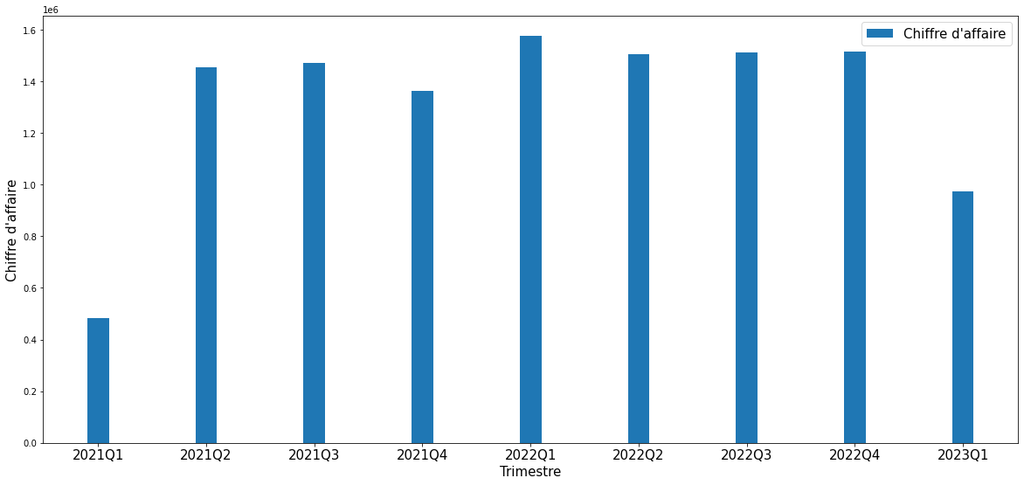

```python
# Création des trimestres
import pandas as pd
pd.options.mode.chained_assignment = None  # default='warn'

evol_vente['trimestre'] = evol_vente['date'].dt.to_period('Q')
print(evol_vente.head())

# Chiffre d'affaire par trimestre pour les 3 années
evol_vente_trim = evol_vente.groupby('trimestre')['price'].sum()
evol_vente_trim = evol_vente_trim.to_frame().reset_index()
print(evol_vente_trim.head())

# Trimestre 2021
evol_vente_2021 = evol_vente[(evol_vente['date'] > '2020-12-31') & (evol_vente['date'] <= '2021-12-31')]
print(evol_vente_2021.head())

# Trimestre 2022
evol_vente_2022 = evol_vente[(evol_vente['date'] > '2021-12-31') & (evol_vente['date'] <= '2022-12-31')]
print(evol_vente_2022.head())

# Trimestre 2023
evol_vente_2023 = evol_vente[(evol_vente['date'] > '2022-12-31') & (evol_vente['date'] <= '2023-12-31')]
print(evol_vente_2023.head())

# Visualisation du CA en fonction des trimestres
# Data
x = np.arange(9)
y = evol_vente_trim['price']
width = 0.2

plt.figure(figsize=[20, 9])

# Création du diagramme
plt.bar(x, y, width)
plt.xticks(x, ["2021Q1", "2021Q2", "2021Q3", "2021Q4", "2022Q1", "2022Q2", "2022Q3", "2022Q4", "2023Q1"], fontsize=15)
plt.xlabel("Trimestre", fontsize=15)
plt.ylabel("Chiffre d'affaire", fontsize=15)
plt.legend(["Chiffre d'affaire"], fontsize=15)
plt.show()
```

2.3. Tendance globale et décomposition en moyenne mobile

```python
# Moyenne sur une semaine et un mois
evol_vente['7day_rolling_avg'] = evol_vente.price.rolling(7).mean()
evol_vente['30day_rolling_avg'] = evol_vente.price.rolling(30).mean()
display(evol_vente.head(10))
```

|  | date | price | trimestre | 7day_rolling_avg | 30day_rolling_avg |
| --- | --- | --- | --- | --- | --- |
| 0 | 2021-03-01 | 16575.85 | 2021Q1 | NaN | NaN |
| 1 | 2021-03-02 | 15497.08 | 2021Q1 | NaN | NaN |
| 2 | 2021-03-03 | 15198.69 | 2021Q1 | NaN | NaN |
| 3 | 2021-03-04 | 15196.07 | 2021Q1 | NaN | NaN |
| 4 | 2021-03-05 | 17471.37 | 2021Q1 | NaN | NaN |
| 5 | 2021-03-06 | 15785.28 | 2021Q1 | NaN | NaN |
| 6 | 2021-03-07 | 14770.83 | 2021Q1 | 15785.024286 | NaN |
| 7 | 2021-03-08 | 15679.53 | 2021Q1 | 15656.978571 | NaN |
| 8 | 2021-03-09 | 15710.51 | 2021Q1 | 15687.468571 | NaN |
| 9 | 2021-03-10 | 15496.87 | 2021Q1 | 15730.065714 | NaN |

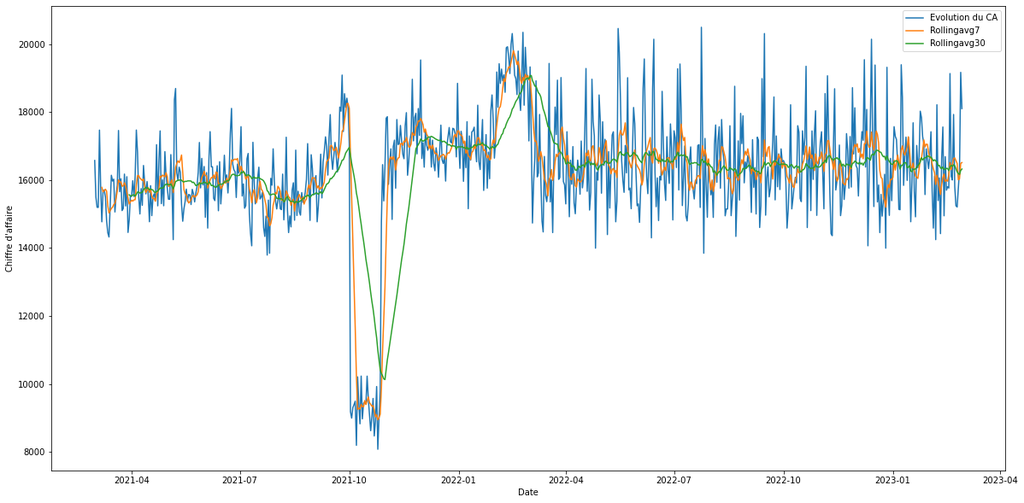

```python
# Série temporelle
fig = plt.figure( figsize = (20, 10))

sns.lineplot(x = 'date',
             y = 'price',
             data = evol_vente,
             label = 'Evolution du CA')

sns.lineplot(x = 'date',
             y = '7day_rolling_avg',
             data = evol_vente,
             label = 'Rollingavg7')

sns.lineplot(x = 'date',
             y = '30day_rolling_avg',
             data = evol_vente,
             label = 'Rollingavg30')

plt.xlabel('Date')
plt.ylabel("Chiffre d'affaire")

fig.savefig('evol_my.png')
```

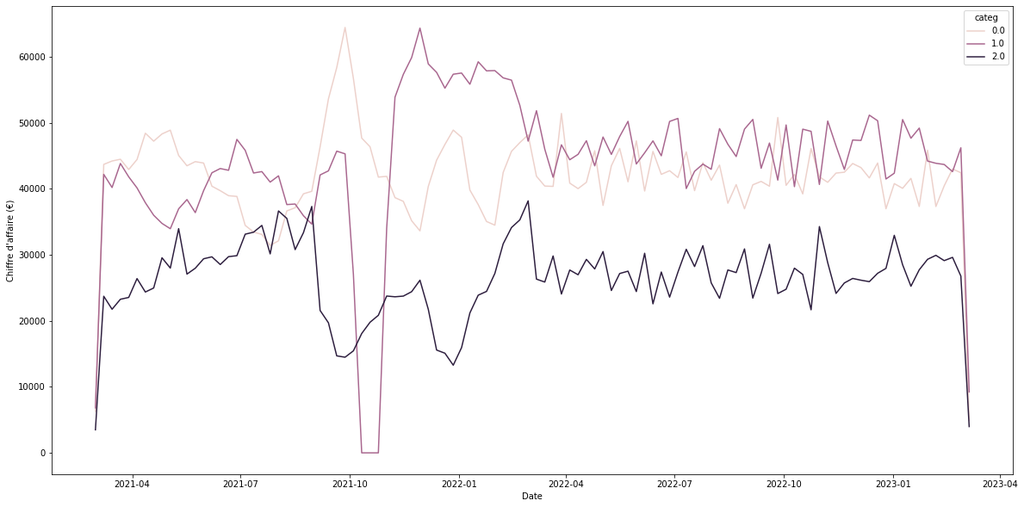

```python
# Visualisation des ventes par catégories
suivi_categ = rapprochement.set_index('date').groupby('categ').resample('W-MON').agg({'price':'sum'})
suivi_categ = suivi_categ.reset_index(level=0)

from matplotlib import pyplot as plt
import seaborn as sns

# Visualisation du CA en fct du temps
plt.figure(figsize = (20, 10))

sns.lineplot(x = 'date',
             y = 'price',
             hue = 'categ',
             data = suivi_categ)

plt.xlabel('Date')
plt.ylabel("Chiffre d'affaire (€)")
```

```python
# Suppression du mois d'octobre 2021 pour toutes les catégories car pas de ventes dans la catégorie 1 en octobre 2021
rapprochement = rapprochement[(rapprochement.date <= "2021-10-01") | (rapprochement.date >= "2021-10-31")]
rapprochement

#Calcul chiffre d'affaire total sans octobre 2021
chiffre_affaire2 = rapprochement['price'].sum()
print("Le chiffre d'affaire total est de", round(chiffre_affaire2,2),"€.")
```

```
Le chiffre d'affaire total est de 11568668.22 €.
```

|  | date | price | 7day_rolling_avg | 30day_rolling_avg |
| --- | --- | --- | --- | --- |
| 0 | 2021-03-01 | 16575.85 | NaN | NaN |
| 1 | 2021-03-02 | 15497.08 | NaN | NaN |
| 2 | 2021-03-03 | 15198.69 | NaN | NaN |
| 3 | 2021-03-04 | 15196.07 | NaN | NaN |
| 4 | 2021-03-05 | 17471.37 | NaN | NaN |
| 5 | 2021-03-06 | 15785.28 | NaN | NaN |
| 6 | 2021-03-07 | 14770.83 | 15785.024286 | NaN |
| 7 | 2021-03-08 | 15679.53 | 15656.978571 | NaN |
| 8 | 2021-03-09 | 15710.51 | 15687.468571 | NaN |
| 9 | 2021-03-10 | 15496.87 | 15730.065714 | NaN |

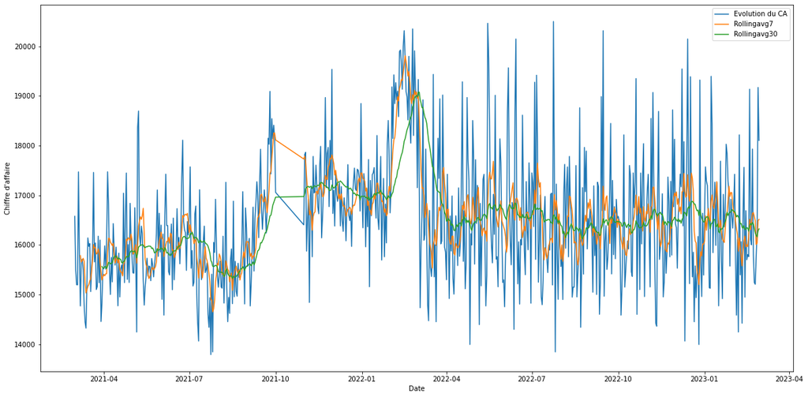

```python
evol_vente2 = rapprochement.groupby('date')['price'].sum().to_frame().reset_index()

# Moyenne sur une semaine et un mois
evol_vente2['7day_rolling_avg'] = evol_vente2.price.rolling(7).mean()
evol_vente2['30day_rolling_avg'] = evol_vente2.price.rolling(30).mean()
display(evol_vente2.head(10))

# Série temporelle
fig = plt.figure( figsize = (20, 10))

sns.lineplot(x = 'date',
             y = 'price',
             data = evol_vente2,
             label = 'Evolution du CA')

sns.lineplot(x = 'date',
             y = '7day_rolling_avg',
             data = evol_vente2,
             label = 'Rollingavg7')

sns.lineplot(x = 'date',
             y = '30day_rolling_avg',
             data = evol_vente2,
             label = 'Rollingavg30')

plt.xlabel('Date')
plt.ylabel("Chiffre d'affaire")

fig.savefig('evol_my2.png')
```

2.4. Profils clients

2.4.1. Catégories d'âge

|  | id_prod | price | categ | date | session_id | client_id | sex | birth | age |
| --- | --- | --- | --- | --- | --- | --- | --- | --- | --- |
| 0 | 0_1518 | 4.18 | 0.0 | 2022-05-20 | s_211425 | c_103 | f | 1986 | 37 |
| 1 | 0_1627 | 3.99 | 0.0 | 2022-06-18 | s_225494 | c_103 | f | 1986 | 37 |
| 2 | 0_1104 | 13.21 | 0.0 | 2023-02-08 | s_338755 | c_103 | f | 1986 | 37 |
| 3 | 0_1390 | 19.37 | 0.0 | 2021-04-20 | s_23078 | c_103 | f | 1986 | 37 |
| 4 | 0_1547 | 8.99 | 0.0 | 2022-03-15 | s_179629 | c_103 | f | 1986 | 37 |

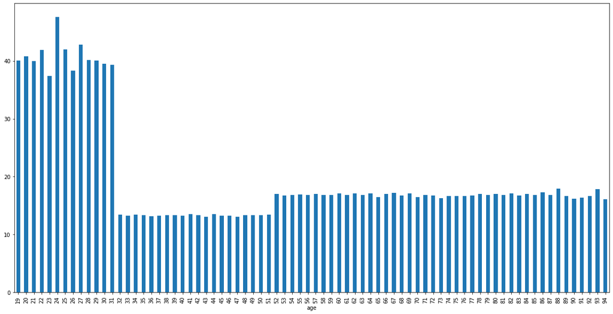

```python
#Ajout d'une colonne "age" pour calculer l'âge des clients à partir de leur année de naissance
rapprochement.insert(loc=8, column='age', value= 2023-rapprochement.birth, allow_duplicates=True)

display(rapprochement.head())

#Visualisation de la distribution des ventes par âge
fig, ax = plt.subplots(figsize=(20, 10))
rapprochement.groupby('age')['price'].mean().plot(kind='bar')

#Définition des différentes catégories d'âge
pd.cut(rapprochement['age'], bins= [18, 31, 51, 94])

#Definition de catégories d'âge
rapprochement["tranche_age"] = pd.cut(rapprochement['age'], bins= [18, 31, 51, 94])
rapprochement.tranche_age.unique()

#Conversion du type de données
rapprochement['tranche_age'] = rapprochement['tranche_age'].astype(str)
```

2.4.2. Top clients

```python
top_client = rapprochement.groupby('client_id')['price'].sum().sort_values(ascending=False)

#Top 10 client
top_client.head(10)
```

```
client_id
c_1609    313587.24
c_4958    283275.43
c_6714    150276.43
c_3454    112075.73
c_2899      5214.05
c_1570      5166.45
c_7319      5131.74
c_3263      5129.89
c_5263      5006.85
c_8026      4980.04
Name: price, dtype: float64
```

```python
#Visualisation des 4 tops clients
client_1609 = rapprochement.loc[rapprochement['client_id'] == 'c_1609']
client_4958 = rapprochement.loc[rapprochement['client_id'] == 'c_4958']
client_6714 = rapprochement.loc[rapprochement['client_id'] == 'c_6714']
client_3454 = rapprochement.loc[rapprochement['client_id'] == 'c_3454']

display(client_1609.head(5))
display(client_4958.head(5))
display(client_6714.head(5))
display(client_3454.head(5))
```

|  | id_prod | price | categ | date | session_id | client_id | sex | birth | age | tranche_age |
| --- | --- | --- | --- | --- | --- | --- | --- | --- | --- | --- |
| 22561 | 0_1446 | 8.09 | 0.0 | 2022-10-05 | s_278030 | c_1609 | m | 1980 | 43 | (31, 51] |
| 22564 | 0_2291 | 12.99 | 0.0 | 2021-03-07 | s_3088 | c_1609 | m | 1980 | 43 | (31, 51] |
| 22565 | 0_1611 | 11.99 | 0.0 | 2022-03-06 | s_175223 | c_1609 | m | 1980 | 43 | (31, 51] |
| 22566 | 0_1468 | 6.08 | 0.0 | 2021-06-17 | s_49752 | c_1609 | m | 1980 | 43 | (31, 51] |
| 22567 | 1_246 | 18.75 | 1.0 | 2022-09-07 | s_264836 | c_1609 | m | 1980 | 43 | (31, 51] |

|  | id_prod | price | categ | date | session_id | client_id | sex | birth | age | tranche_age |
| --- | --- | --- | --- | --- | --- | --- | --- | --- | --- | --- |
| 13427 | 1_426 | 19.44 | 1.0 | 2021-06-21 | s_51846 | c_4958 | m | 1999 | 24 | (18, 31] |
| 13428 | 1_506 | 13.65 | 1.0 | 2021-09-29 | s_97203 | c_4958 | m | 1999 | 24 | (18, 31] |
| 13429 | 1_536 | 11.21 | 1.0 | 2021-11-06 | s_115771 | c_4958 | m | 1999 | 24 | (18, 31] |
| 13430 | 2_109 | 53.99 | 2.0 | 2022-12-21 | s_315377 | c_4958 | m | 1999 | 24 | (18, 31] |
| 13431 | 2_154 | 96.74 | 2.0 | 2021-06-14 | s_48642 | c_4958 | m | 1999 | 24 | (18, 31] |

|  | id_prod | price | categ | date | session_id | client_id | sex | birth | age | tranche_age |
| --- | --- | --- | --- | --- | --- | --- | --- | --- | --- | --- |
| 442 | 0_1277 | 7.99 | 0.0 | 2022-06-18 | s_225667 | c_6714 | f | 1968 | 55 | (51, 94] |
| 443 | 1_661 | 22.99 | 1.0 | 2022-09-13 | s_267366 | c_6714 | f | 1968 | 55 | (51, 94] |
| 445 | 1_446 | 23.92 | 1.0 | 2022-02-04 | s_159894 | c_6714 | f | 1968 | 55 | (51, 94] |
| 446 | 1_445 | 23.99 | 1.0 | 2022-08-24 | s_257657 | c_6714 | f | 1968 | 55 | (51, 94] |
| 447 | 0_1432 | 15.36 | 0.0 | 2021-05-13 | s_33987 | c_6714 | f | 1968 | 55 | (51, 94] |

|  | id_prod | price | categ | date | session_id | client_id | sex | birth | age | tranche_age |
| --- | --- | --- | --- | --- | --- | --- | --- | --- | --- | --- |
| 58811 | 1_731 | 11.99 | 1.0 | 2022-11-12 | s_296642 | c_3454 | m | 1969 | 54 | (51, 94] |
| 58812 | 1_622 | 17.41 | 1.0 | 2022-06-11 | s_221971 | c_3454 | m | 1969 | 54 | (51, 94] |
| 58813 | 0_1280 | 11.96 | 0.0 | 2023-01-15 | s_327467 | c_3454 | m | 1969 | 54 | (51, 94] |
| 58814 | 1_285 | 14.99 | 1.0 | 2021-12-16 | s_135210 | c_3454 | m | 1969 | 54 | (51, 94] |
| 58815 | 0_1197 | 6.99 | 0.0 | 2022-06-27 | s_230067 | c_3454 | m | 1969 | 54 | (51, 94] |

```python
# Panier my pour ces clients là
client_1609_panier_my = client_1609.groupby(["session_id"])['price'].mean().mean()
print(client_1609_panier_my)

client_4958_panier_my = client_4958.groupby(["session_id"])['price'].mean().mean()
print(client_4958_panier_my)

client_6714_panier_my = client_6714.groupby(["session_id"])['price'].mean().mean()
print(client_6714_panier_my)

client_3454_panier_my = client_3454.groupby(["session_id"])['price'].mean().mean()
print(client_3454_panier_my)
```

```
13.094698227936743
54.792478095742005
17.466366917931158
16.480831349206824
```

```python
#Fréquence d'achat de ces clients là / Nombre moyen de commandes par jour
client_1609_freq = client_1609.groupby(['date']).size().mean()
print(client_1609_freq)

client_4958_freq = client_4958.groupby(['date']).size().mean()
print(client_4958_freq)

client_6714_freq = client_6714.groupby(['date']).size().mean()
print(client_6714_freq)

client_3454_freq = client_3454.groupby(['date']).size().mean()
print(client_3454_freq)
```

```
35.00427960057061
7.322812051649929
13.21301775147929
9.489300998573466
```

2.4.3. Courbe de Lorenz et part des clients sur le chiffre d'affaire

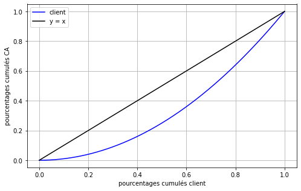

```python
top_client = top_client.to_frame().reset_index()

# Courbe de Lorenz
import numpy as np
import pandas as pd
import matplotlib.pyplot as plt

# 'Ct' Ajoutez une colonne numérique appelée
top_client['Ct']=np.arange(1,len(top_client)+1)

# Remplacez x par une chaîne numérique
x = top_client['Ct']

# Remplacer la valeur cumulée des données G1 par y
y = top_client['Ct'].cumsum()

# Dessin graphique
fig, (ax1) = plt.subplots(1, 1, figsize=(8,5))

# x,Normaliser avec la valeur maximale de y et dessiner avec une ligne bleue
ax1.plot(x/max(x),y/max(y),'blue', label='client')

# En tant que distribution uniforme, y=Dessin graphique de x
ax1.plot(x/max(x),x/max(x),'black', label = 'y = x')

# Dessinez la distribution de fréquence sur ax2
ax1.set_xlabel('pourcentages cumulés client')
ax1.set_ylabel('pourcentages cumulés CA')
ax1.legend()
ax1.grid(True)
plt.show()
```

```python
# Calcul coeff Gini
def gini_coefficient(x):
    """Compute Gini coefficient of array of values"""
    diffsum = 0
    for i, xi in enumerate(x[:-1], 1):
        diffsum += np.sum(np.abs(xi - x[i:]))
    return diffsum / (len(x)**2 * np.mean(x))

gini_coefficient(top_client['Ct'])
```

```
0.33329456462743273
```

2.5. Zoom sur les références

2.5.1. Top/flop références

```python
top_vente_ref = rapprochement.groupby('id_prod')['session_id'].count().sort_values(ascending=False)
top_vente_ref.head(10)
```

```
id_prod
1_369    2244
1_417    2177
1_414    2174
1_498    2123
1_425    2088
1_403    1952
1_412    1946
1_413    1937
1_406    1935
1_407    1928
Name: session_id, dtype: int64
```

```python
flop_vente_ref = rapprochement.groupby('id_prod')['price'].count().sort_values(ascending=True)
flop_vente_ref.head(21)
```

```
id_prod
0_1498    1
0_1151    1
0_833     1
0_807     1
0_1601    1
0_1595    1
0_886     1
0_549     1
0_1284    1
2_81      1
0_541     1
0_1633    1
0_898     1
0_1533    1
0_980     1
2_98      1
0_1539    1
0_1728    1
2_23      1
0_1683    1
0_1726    2
Name: price, dtype: int64
```

```python
rapprochement.loc[rapprochement['id_prod'] == '0_1498']
```

|  | id_prod | price | categ | date | session_id | client_id | sex | birth | age | tranche_age |
| --- | --- | --- | --- | --- | --- | --- | --- | --- | --- | --- |
| 95196 | 0_1498 | 2.48 | 0.0 | 2022-02-19 | s_167516 | c_1938 | f | 1979 | 44 | (31, 51] |

```python
top_ca_ref = rapprochement.groupby('id_prod')['price'].sum().sort_values(ascending=False)
top_ca_ref.head(10)
```

```
id_prod
2_159    92557.66
2_135    67610.20
2_112    63042.81
2_102    59140.00
2_209    55572.06
1_395    54124.33
1_369    53833.56
2_110    51916.50
1_414    51806.42
2_39     51263.16
Name: price, dtype: float64
```

```python
flop_ca_ref = rapprochement.groupby('id_prod')['price'].sum().sort_values(ascending=True)
flop_ca_ref.head(10)
```

```
id_prod
0_1539    0.99
0_898     1.27
0_1284    1.38
0_643     1.98
0_1653    1.98
0_1601    1.99
0_807     1.99
0_541     1.99
0_1728    2.27
0_324     2.36
Name: price, dtype: float64
```

2.5.2. Chiffre d'affaire par catégorie

```python
top_categorie = rapprochement.groupby('categ')['price'].sum().sort_values(ascending=False)
top_categorie
```

```
categ
1.0    4.634226e+06
0.0    4.235630e+06
2.0    2.698813e+06
Name: price, dtype: float64
```

[figure not shown]

```python
# Package
import matplotlib.pyplot as plt
import numpy as np

# Data
x = np.arange(3)
y = top_categorie
width = 0.2

plt.figure(figsize=[7, 9])

# Création du diagramme
plt.bar(x, y, width)
plt.xticks(x, ["0", "1", "2"], fontsize=15)
plt.xlabel("Catégorie", fontsize=15)
plt.ylabel("Chiffre d'affaire", fontsize=15)
plt.legend(["Catégorie"], fontsize=15)
plt.show()
```

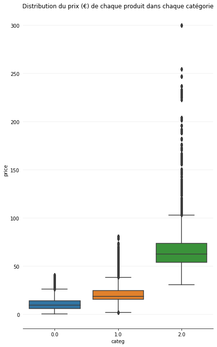

```python
# Visualisation du prix par catégorie

fig, ax = plt.subplots(figsize=(7, 12))
# Remove top and right border
ax.spines['top'].set_visible(False)
ax.spines['right'].set_visible(False)
ax.spines['left'].set_visible(False)
# Remove y-axis tick marks
ax.yaxis.set_ticks_position('none')
# Add major gridlines in the y-axis
ax.grid(color='grey', axis='y', linestyle='-', linewidth=0.25, alpha=0.5)
# Set plot title
ax.set_title("Distribution du prix (€) de chaque produit dans chaque catégorie")
# Boxplot
sns.boxplot(x='categ', y='price', data=rapprochement)
plt.show()
```

2.6. Analyse additionnelle : achats combinés

```python
## idées analyses:
#association: deux articles différents fréquemment achetés lors de la même transaction
```

```python
test_asso = rapprochement.groupby('session_id')['id_prod'].unique().to_frame().reset_index()
test_asso.id_prod
```

```
0                                                  [0_1259]
1                                                   [1_635]
2                                          [0_1030, 0_1451]
3                          [0_1438, 0_1625, 0_1590, 0_1449]
4                                   [0_1324, 0_1418, 1_395]
                                ...
331737                                      [0_1514, 1_635]
331738    [0_1579, 0_1007, 1_379, 1_397, 1_431, 0_1411, ...
331739                                             [0_1457]
331740                                             [0_1623]
331741                             [0_1688, 0_1580, 0_1384]
Name: id_prod, Length: 331742, dtype: object
```

```python
lst_lists = [list(lst) for lst in test_asso['id_prod'].to_list()]
```

```python
# column 'Name' as series object
print(type(test_asso['id_prod']))

# Convert series object to a list
print(type(test_asso['id_prod'].values.tolist()))
```

```
<class 'pandas.core.series.Series'>
<class 'list'>
```

```python
dic = dict()
```

```python
for lst in lst_lists:
    for id_prod in lst:
        dic[id_prod] = dict()
```

```python
for id_prod in dic:
    for lst in lst_lists:
        if id_prod in lst:
            for i in lst:
                if i not in dic[id_prod]:
                    if i != id_prod:
                        dic[id_prod][i] = 1
                else:
                    if i != id_prod:
                        dic[id_prod][i] += 1
```

```python
for key,value in dic.items():
    for k,v in value.items():
        if v > 10:
            print(key)
```

[output not shown]

[output cut: 2483 more lines]

[output not shown]

```python
{k:v for k,v in dic["2_159"].items() if v>2}
```

```
{'0_525': 489,
 '1_247': 3,
 '0_1547': 6,
 '0_1029': 3,
 '0_1334': 5,
 '0_1349': 7,
 '0_1599': 6,
 '0_1438': 4,
 '1_367': 6,
 '0_1140': 3,
 '1_414': 3,
 '0_1330': 3,
 '0_1428': 3,
 '1_442': 4,
 '1_426': 7,
 '1_249': 5,
 '0_1157': 4,
 '1_274': 3,
 '1_162': 3,
 '0_1391': 3,
 '0_1568': 3,
 '1_451': 3,
 '1_412': 5,
 '0_2054': 3,
 '1_601': 5,
 '0_1445': 3,
 '1_376': 8,
 '1_362': 3,
 '0_1083': 4,
 '1_413': 3,
 '1_406': 9,
 '1_730': 4,
 '1_310': 3,
 '0_1414': 3,
 '0_1475': 3,
 '0_1333': 4,
 '1_366': 5,
 '1_400': 5,
 '2_108': 4,
 '0_1351': 3,
```

[output cut: 137 more lines]

```
 '1_381': 3,
 '0_1266': 3,
 '1_488': 4,
 '0_1430': 3,
 '0_1145': 3,
 '0_1409': 3,
 '0_1385': 3,
 '0_1392': 3,
 '0_1075': 3,
 '0_1111': 4,
 '1_379': 4,
 '1_453': 3,
 '0_1472': 3,
 '2_37': 3,
 '0_1358': 3}
```

==> Exemple : L'article 2_159 a été acheté 489 fois avec l'article 0_525.

# 3. Analyse des comportements clients (w/o top clients)

```python
rapprochement.head(5)
```

|  | id_prod | price | categ | date | session_id | client_id | sex | birth | age | tranche_age |
| --- | --- | --- | --- | --- | --- | --- | --- | --- | --- | --- |
| 0 | 0_1518 | 4.18 | 0.0 | 2022-05-20 | s_211425 | c_103 | f | 1986 | 37 | (31, 51] |
| 1 | 0_1627 | 3.99 | 0.0 | 2022-06-18 | s_225494 | c_103 | f | 1986 | 37 | (31, 51] |
| 2 | 0_1104 | 13.21 | 0.0 | 2023-02-08 | s_338755 | c_103 | f | 1986 | 37 | (31, 51] |
| 3 | 0_1390 | 19.37 | 0.0 | 2021-04-20 | s_23078 | c_103 | f | 1986 | 37 | (31, 51] |
| 4 | 0_1547 | 8.99 | 0.0 | 2022-03-15 | s_179629 | c_103 | f | 1986 | 37 | (31, 51] |

```python
# Sélection clients hors top
clients_amateurs = rapprochement[-rapprochement["client_id"].isin(["c_4958","c_6714", "c_1609", "c_3454"])]
display(clients_amateurs.head())
```

|  | id_prod | price | categ | date | session_id | client_id | sex | birth | age | tranche_age |
| --- | --- | --- | --- | --- | --- | --- | --- | --- | --- | --- |
| 0 | 0_1518 | 4.18 | 0.0 | 2022-05-20 | s_211425 | c_103 | f | 1986 | 37 | (31, 51] |
| 1 | 0_1627 | 3.99 | 0.0 | 2022-06-18 | s_225494 | c_103 | f | 1986 | 37 | (31, 51] |
| 2 | 0_1104 | 13.21 | 0.0 | 2023-02-08 | s_338755 | c_103 | f | 1986 | 37 | (31, 51] |
| 3 | 0_1390 | 19.37 | 0.0 | 2021-04-20 | s_23078 | c_103 | f | 1986 | 37 | (31, 51] |
| 4 | 0_1547 | 8.99 | 0.0 | 2022-03-15 | s_179629 | c_103 | f | 1986 | 37 | (31, 51] |

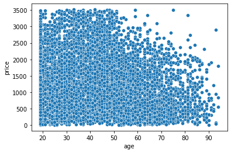

```python
# Distribution des valeurs quantitatives
test = clients_amateurs.groupby(['client_id', 'age'])['price'].sum().reset_index()
third_quartile = test['price'].quantile(0.75)
first_quartile =  test['price'].quantile(0.25)
iqr =   third_quartile - first_quartile

mask = (test['price'] > third_quartile + 1.5 * iqr) | (test['price'] < first_quartile - 1.5 * iqr)

sns.scatterplot(x='age', y='price', data=test.loc[~mask])
```

```python
#Test de la distribution normale avec D'Agostino car N > 5000 // H0 : Distribution normale

from scipy import stats

k2, p = stats.normaltest(clients_amateurs.price)
alpha = 1e-3

print("p = {:g}".format(p))
if p < alpha:  # null hypothesis: x comes from a normal distribution
    print("The null hypothesis can be rejected")
else:
    print("The null hypothesis cannot be rejected")
```

```
p = 0
The null hypothesis can be rejected
```

```python
#Test de la distribution normale avec D'Agostino car N > 5000 // H0 : Distribution normale

from scipy import stats

k2, p = stats.normaltest(clients_amateurs.age)
alpha = 1e-3

print("p = {:g}".format(p))
if p < alpha:  # null hypothesis: x comes from a normal distribution
    print("The null hypothesis can be rejected")
else:
    print("The null hypothesis cannot be rejected")
```

```
p = 0
The null hypothesis can be rejected
```

3.1. Lien entre le genre d'un client et les catégories de livres achetées

```python
#Lien entre genre client et categorie livre acheté
genre_cat = pd.crosstab(clients_amateurs.categ, clients_amateurs.sex)
genre_cat
```

| sex categ | f | m |
| --- | --- | --- |
| 0.0 | 192609 | 178597 |
| 1.0 | 110875 | 100550 |
| 2.0 | 16476 | 15376 |

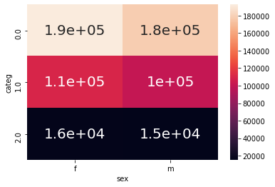

```python
#Heatmap
# libraries
import seaborn as sns
import pandas as pd
import numpy as np

# plot a heatmap with annotation
sns.heatmap(genre_cat, annot=True, annot_kws={"size": 20})
```

```python
#load necessary packages and functions
import scipy.stats as stats
import numpy as np

#Chi-squared test statistic, sample size, and minimum of rows and columns
X2, p, dof, ex = stats.chi2_contingency(genre_cat, correction=False)
print(p)
n = np.sum(genre_cat)
minDim = min(genre_cat.shape)-1

#calculate Cramer's V
V = np.sqrt((X2/n) / minDim)

#display Cramer's V
print(V)
```

```
0.00011315108351543654
sex
f    0.007537
m    0.007855
dtype: float64
```

==> Lien entre le genre et la catégorie achetée, mais lien pas très fort

3.2. Lien entre l'âge et le montant total des achats

```python
total_session = clients_amateurs.groupby(["tranche_age", 'session_id'])['price'].sum().to_frame().reset_index()
display(total_session.head())
```

|  | tranche_age | session_id | price |
| --- | --- | --- | --- |
| 0 | (18, 31] | s_10002 | 64.85 |
| 1 | (18, 31] | s_10030 | 59.14 |
| 2 | (18, 31] | s_10033 | 30.05 |
| 3 | (18, 31] | s_10035 | 46.31 |
| 4 | (18, 31] | s_10040 | 119.84 |

==> le prix n'est pas distribué de manière normale

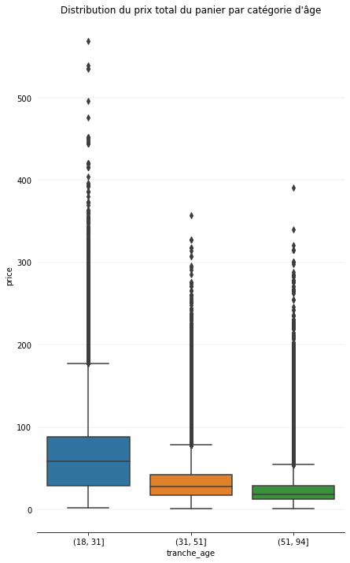

```python
# Visualisation du total_session par catégorie d'âge

fig, ax = plt.subplots(figsize=(7, 12))
# Remove top and right border
ax.spines['top'].set_visible(False)
ax.spines['right'].set_visible(False)
ax.spines['left'].set_visible(False)
# Remove y-axis tick marks
ax.yaxis.set_ticks_position('none')
# Add major gridlines in the y-axis
ax.grid(color='grey', axis='y', linestyle='-', linewidth=0.25, alpha=0.5)
# Set plot title
ax.set_title("Distribution du prix total du panier par catégorie d'âge")
# Boxplot
sns.boxplot(x='tranche_age', y='price', data=total_session)
plt.show()
```

```python
myCoding = {'(18, 31]' : 1, '(31, 51]' : 2, '(51, 94]' : 3}
total_session["tranche_age_req"] = total_session["tranche_age"].replace(myCoding)
```

```python
import numpy as np
import pingouin as pg

from pingouin import kruskal

#Kruskal-Wallis - The median of all groups are the same
#H0 : pas de différence entre les échantillons (ou groupe)
#H1 : au moins un échantillon (ou groupe) est différent d'un autre
kruskal(data = total_session, dv = 'price', between = 'tranche_age_req')
```

|  | Source | ddof1 | H | p-unc |
| --- | --- | --- | --- | --- |
| Kruskal | tranche_age_req | 2 | 48816.918692 | 0.0 |

==> au moins un groupe est différent des autres

```python
from statannotations.Annotator import Annotator
%matplotlib inline
import matplotlib.pyplot as plt
import seaborn as sns
import pandas as pd
```

```
p-value annotation legend:
      ns: p <= 1.00e+00
       *: 1.00e-02 < p <= 5.00e-02
      **: 1.00e-03 < p <= 1.00e-02
     ***: 1.00e-04 < p <= 1.00e-03
    ****: p <= 1.00e-04

(18, 31] vs. (31, 51]: Kruskal-Wallis independent samples (pairwise between groups), P_val:0.000e+00 Stat=2.588e+04
(31, 51] vs. (51, 94]: Kruskal-Wallis independent samples (pairwise between groups), P_val:0.000e+00 Stat=1.519e+04
(18, 31] vs. (51, 94]: Kruskal-Wallis independent samples (pairwise between groups), P_val:0.000e+00 Stat=3.955e+04
```

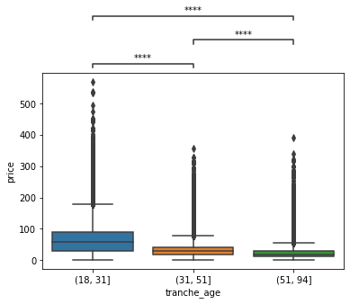

```python
#Kruskal-Wallis détaillé entre chaque groupe
x = "tranche_age"
y = "price"
order = ['(18, 31]', '(31, 51]', '(51, 94]']

#Boxplot
ax = sns.boxplot(data=total_session, x=x, y=y, order=order)

#Annotation
annot = Annotator(ax, [("(18, 31]", "(31, 51]"), ("(18, 31]", "(51, 94]"), ("(31, 51]", "(51, 94]")], data=total_session, x=x, y=y, order=order)
annot.configure(test='Kruskal', text_format='star', loc='outside', verbose=2)
annot.apply_test()
ax, test_results = annot.annotate()

#Sauvegarde de la figure
plt.savefig('total_session_test.png', dpi=300, bbox_inches='tight')
```

4.3. Lien entre l'âge et la fréquence d'achat

```python
# Fréquence d'achat par tranche d'âge
freq_achat_date_age = clients_amateurs.groupby(['date', 'tranche_age']).size()
freq_achat_date_age = freq_achat_date_age.to_frame().reset_index()

# Changement du nom de la colonne avec le nombre d'achat
freq_achat_date_age.rename(columns={0: 'freq'}, inplace=True)

freq_achat_date_age.head()
```

|  | date | tranche_age | freq |
| --- | --- | --- | --- |
| 0 | 2021-03-01 | (18, 31] | 103 |
| 1 | 2021-03-01 | (31, 51] | 560 |
| 2 | 2021-03-01 | (51, 94] | 243 |
| 3 | 2021-03-02 | (18, 31] | 94 |
| 4 | 2021-03-02 | (31, 51] | 552 |

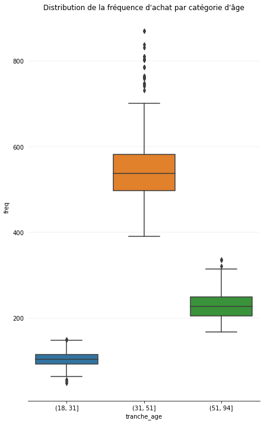

```python
# Visualisation de la fréquence d'achats par catégorie d'âge

fig, ax = plt.subplots(figsize=(7, 12))
# Remove top and right border
ax.spines['top'].set_visible(False)
ax.spines['right'].set_visible(False)
ax.spines['left'].set_visible(False)
# Remove y-axis tick marks
ax.yaxis.set_ticks_position('none')
# Add major gridlines in the y-axis
ax.grid(color='grey', axis='y', linestyle='-', linewidth=0.25, alpha=0.5)
# Set plot title
ax.set_title("Distribution de la fréquence d'achat par catégorie d'âge")
# Boxplot
sns.boxplot(x='tranche_age', y='freq', data=freq_achat_date_age)
plt.show()
```

```python
#Test de la distribution normale avec D'Agostino car N > 5000 // H0 : Distribution normale

from scipy import stats

k2, p = stats.normaltest(freq_achat_date_age.freq)
alpha = 1e-3

print("p = {:g}".format(p))
if p < alpha:  # null hypothesis: x comes from a normal distribution
    print("The null hypothesis can be rejected")
else:
    print("The null hypothesis cannot be rejected")
```

```
p = 5.14215e-108
The null hypothesis can be rejected
```

```python
import numpy as np
import pingouin as pg

from pingouin import kruskal

#Kruskal-Wallis
#H0 : pas de différence entre les échantillons (ou groupe)
#H1 : au moins un échantillon (ou groupe) est différent d'un autre
kruskal(data = freq_achat_date_age, dv = 'freq', between = 'tranche_age')
```

|  | Source | ddof1 | H | p-unc |
| --- | --- | --- | --- | --- |
| Kruskal | tranche_age | 2 | 1868.493432 | 0.0 |

==> au moins un groupe est différent des autres

```
p-value annotation legend:
      ns: p <= 1.00e+00
       *: 1.00e-02 < p <= 5.00e-02
      **: 1.00e-03 < p <= 1.00e-02
     ***: 1.00e-04 < p <= 1.00e-03
    ****: p <= 1.00e-04

(18, 31] vs. (31, 51]: Kruskal-Wallis independent samples (pairwise between groups), P_val:1.614e-230 Stat=1.051e+03
(31, 51] vs. (51, 94]: Kruskal-Wallis independent samples (pairwise between groups), P_val:1.648e-230 Stat=1.051e+03
(18, 31] vs. (51, 94]: Kruskal-Wallis independent samples (pairwise between groups), P_val:1.602e-230 Stat=1.051e+03
```

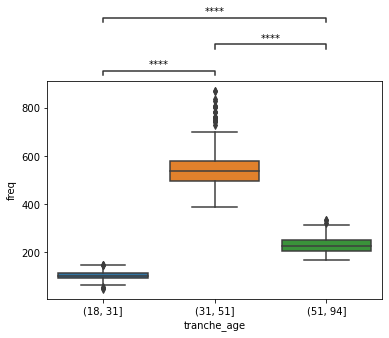

```python
#Kruskal-Wallis détaillé entre chaque groupe
x = "tranche_age"
y = "freq"
order = ['(18, 31]', '(31, 51]', '(51, 94]']

#Boxplot
ax = sns.boxplot(data=freq_achat_date_age, x=x, y=y, order=order)

#Annotation
annot = Annotator(ax, [("(18, 31]", "(31, 51]"), ("(18, 31]", "(51, 94]"), ("(31, 51]", "(51, 94]")], data=freq_achat_date_age, x=x, y=y, order=order)
annot.configure(test='Kruskal', text_format='star', loc='outside', verbose=2)
annot.apply_test()
ax, test_results = annot.annotate()

#Sauvegarde
plt.savefig('freq_achat_date_age_test.png', dpi=300, bbox_inches='tight')
```

4.4. Lien entre l'âge et la taille du panier moyen

```python
panier_session = clients_amateurs.groupby(["tranche_age", "session_id"]).size().to_frame().reset_index()

# Changement du nom de la colonne avec le nombre d'achat par session
panier_session.rename(columns={0: 'taille_panier'}, inplace=True)

panier_session
```

|  | tranche_age | session_id | taille_panier |
| --- | --- | --- | --- |
| 0 | (18, 31] | s_10002 | 1 |
| 1 | (18, 31] | s_10030 | 1 |
| 2 | (18, 31] | s_10033 | 2 |
| 3 | (18, 31] | s_10035 | 1 |
| 4 | (18, 31] | s_10040 | 2 |
| ... | ... | ... | ... |
| 309418 | (51, 94] | s_998 | 2 |
| 309419 | (51, 94] | s_9980 | 1 |
| 309420 | (51, 94] | s_9991 | 2 |
| 309421 | (51, 94] | s_9993 | 1 |
| 309422 | (51, 94] | s_9997 | 1 |

309423 rows × 3 columns

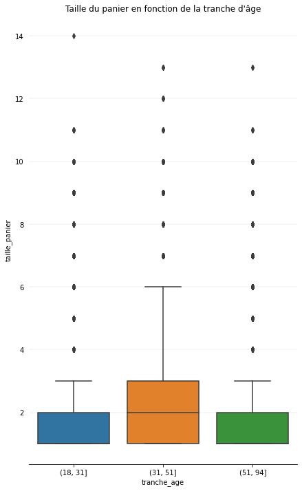

```python
#Boxplot âge / taille du panier

fig, ax = plt.subplots(figsize=(7, 12))
# Remove top and right border
ax.spines['top'].set_visible(False)
ax.spines['right'].set_visible(False)
ax.spines['left'].set_visible(False)
# Remove y-axis tick marks
ax.yaxis.set_ticks_position('none')
# Add major gridlines in the y-axis
ax.grid(color='grey', axis='y', linestyle='-', linewidth=0.25, alpha=0.5)
# Set plot title
ax.set_title("Taille du panier en fonction de la tranche d'âge")
# Boxplot
sns.boxplot(x='tranche_age', y='taille_panier', data=panier_session)
plt.show()
```

```python
#Test de la distribution normale de la taille du panier // H0 : Distribution normale

from scipy import stats

k2, p = stats.normaltest(panier_session.taille_panier)
alpha = 1e-3

print("p = {:g}".format(p))
if p < alpha:  # null hypothesis: x comes from a normal distribution
    print("The null hypothesis can be rejected")
else:
    print("The null hypothesis cannot be rejected")
```

```
p = 0
The null hypothesis can be rejected
```

```python
import numpy as np
import pingouin as pg

from pingouin import kruskal

#Kruskal-Wallis
#H0 : pas de différence entre les échantillons (ou groupe)
#H1 : au moins un échantillon (ou groupe) est différent d'un autre
kruskal(data = panier_session, dv = 'taille_panier', between = 'tranche_age')
```

|  | Source | ddof1 | H | p-unc |
| --- | --- | --- | --- | --- |
| Kruskal | tranche_age | 2 | 57750.149321 | 0.0 |

```
p-value annotation legend:
      ns: p <= 1.00e+00
       *: 1.00e-02 < p <= 5.00e-02
      **: 1.00e-03 < p <= 1.00e-02
     ***: 1.00e-04 < p <= 1.00e-03
    ****: p <= 1.00e-04

(18, 31] vs. (31, 51]: Kruskal-Wallis independent samples (pairwise between groups), P_val:0.000e+00 Stat=1.295e+04
(31, 51] vs. (51, 94]: Kruskal-Wallis independent samples (pairwise between groups), P_val:0.000e+00 Stat=5.457e+04
(18, 31] vs. (51, 94]: Kruskal-Wallis independent samples (pairwise between groups), P_val:0.000e+00 Stat=2.856e+03
```

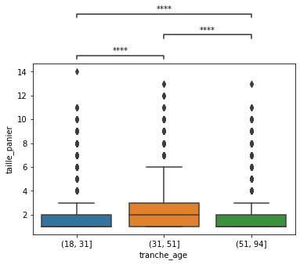

```python
#Kruskal-Wallis détaillé entre chaque groupe
x = "tranche_age"
y = "taille_panier"
order = ['(18, 31]', '(31, 51]', '(51, 94]']

#Boxplot
ax = sns.boxplot(data=panier_session, x=x, y=y, order=order)

#Annotation
annot = Annotator(ax, [("(18, 31]", "(31, 51]"), ("(18, 31]", "(51, 94]"), ("(31, 51]", "(51, 94]")], data=panier_session, x=x, y=y, order=order)
annot.configure(test='Kruskal', text_format='star', loc='outside', verbose=2)
annot.apply_test()
ax, test_results = annot.annotate()

#Sauvegarde
plt.savefig('panier_session_test.png', dpi=300, bbox_inches='tight')
```

4.5. Lien entre l'âge et la catégorie de livre achetée

```python
#Lien entre âge client et categorie livre acheté
```

```python
categ_age = pd.crosstab(rapprochement.categ, rapprochement.tranche_age)
categ_age
```

| tranche_age categ | (18, 31] | (31, 51] | (51, 94] |
| --- | --- | --- | --- |
| 0.0 | 15973 | 306040 | 76116 |
| 1.0 | 29870 | 97678 | 98641 |
| 2.0 | 32198 | 1445 | 1748 |

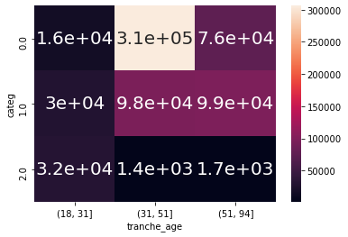

```python
#Heatmap
# libraries
import seaborn as sns
import pandas as pd
import numpy as np

# plot a heatmap with annotation
sns.heatmap(categ_age, annot=True, annot_kws={"size": 20})
```

```python
#load necessary packages and functions
import scipy.stats as stats
import numpy as np

#Chi-squared test statistic, sample size, and minimum of rows and columns
#H0 : pas de différence entre les fréquences ou les proportions des groupes
#H1 : il existe une différence entre les fréquences des groupes, différence qui ne serait pas due au hasard.

X2, p, dof, ex = stats.chi2_contingency(categ_age, correction=False)
print(p)
n = np.sum(categ_age)
minDim = min(categ_age.shape)-1

#calculate Cramer's V
V = np.sqrt((X2/n) / minDim)

#display Cramer's V
print(V)
```

```
0.0
tranche_age
(18, 31]    1.372457
(31, 51]    0.602345
(51, 94]    0.912602
dtype: float64
```

==> p-value = 0, différence significative entre les groupes et lien relativement fort (les 18-31 ans achètent plus dans la catégorie 2, les 31-51ans dans la catégorie 0)

4.6. Lien entre fréquence d'achat et le prix moyen du panier

```python
#Prix moyen par session par client
panier_my_client = clients_amateurs.groupby(["client_id", "date", "session_id"]).mean('price').reset_index()
display(panier_my_client.head(5))

#Panier moyen par client pour le mois de mars 2022
panier_my_client_mars = panier_my_client[(panier_my_client.date >= "2022-03-01") & (panier_my_client.date <= "2022-03-31")]
panier_my_client_mars_grp = panier_my_client_mars.groupby(["client_id"]).mean('price').reset_index()
display(panier_my_client_mars_grp.head(5))
```

|  | client_id | date | session_id | price | categ | birth | age |
| --- | --- | --- | --- | --- | --- | --- | --- |
| 0 | c_1 | 2021-06-11 | s_47346 | 19.53 | 0.0 | 1955 | 68 |
| 1 | c_1 | 2021-07-21 | s_65433 | 11.99 | 0.0 | 1955 | 68 |
| 2 | c_1 | 2021-07-25 | s_66947 | 12.30 | 0.0 | 1955 | 68 |
| 3 | c_1 | 2021-07-26 | s_67467 | 18.94 | 0.0 | 1955 | 68 |
| 4 | c_1 | 2021-07-27 | s_67769 | 11.99 | 0.0 | 1955 | 68 |

|  | client_id | price | categ | birth | age |
| --- | --- | --- | --- | --- | --- |
| 0 | c_1 | 8.990000 | 0.000000 | 1955 | 68 |
| 1 | c_10 | 23.945000 | 1.000000 | 1956 | 67 |
| 2 | c_1000 | 18.794375 | 0.541667 | 1966 | 57 |
| 3 | c_1001 | 15.990000 | 1.000000 | 1982 | 41 |
| 4 | c_1003 | 12.399167 | 0.222222 | 1982 | 41 |

```python
#Fréquence d'achat par client pour le mois de mars 2022
freq_client_mars = panier_my_client_mars.groupby("client_id")["session_id"].count().to_frame().reset_index()

# Changement du nom de la colonne
freq_client_mars.rename(columns={'session_id': 'nb_achat_mars'}, inplace=True)

display(freq_client_mars.head(5))
```

|  | client_id | nb_achat_mars |
| --- | --- | --- |
| 0 | c_1 | 2 |
| 1 | c_10 | 3 |
| 2 | c_1000 | 8 |
| 3 | c_1001 | 1 |
| 4 | c_1003 | 3 |

```python
#Merge des deux tables
freq_panier_my = panier_my_client_mars_grp.merge(freq_client_mars, on='client_id')

# Changement du nom de la colonne avec le nombre d'achat par session
freq_panier_my.rename(columns={'price': 'price_my_session'}, inplace=True)


freq_panier_my
```

|  | client_id | price_my_session | categ | birth | age | nb_achat_mars |
| --- | --- | --- | --- | --- | --- | --- |
| 0 | c_1 | 8.990000 | 0.000000 | 1955 | 68 | 2 |
| 1 | c_10 | 23.945000 | 1.000000 | 1956 | 67 | 3 |
| 2 | c_1000 | 18.794375 | 0.541667 | 1966 | 57 | 8 |
| 3 | c_1001 | 15.990000 | 1.000000 | 1982 | 41 | 1 |
| 4 | c_1003 | 12.399167 | 0.222222 | 1982 | 41 | 3 |
| ... | ... | ... | ... | ... | ... | ... |
| 5826 | c_990 | 11.305278 | 0.097222 | 1984 | 39 | 6 |
| 5827 | c_991 | 12.174167 | 0.111111 | 1978 | 45 | 3 |
| 5828 | c_996 | 18.320000 | 0.500000 | 1970 | 53 | 3 |
| 5829 | c_997 | 21.867222 | 0.777778 | 1994 | 29 | 3 |
| 5830 | c_999 | 13.990000 | 0.666667 | 1964 | 59 | 3 |

5831 rows × 6 columns

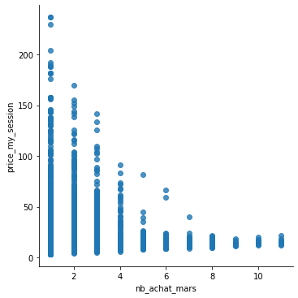

```python
# library
import seaborn as sns
import matplotlib.pyplot as plt

# Plot
sns.lmplot(x="nb_achat_mars", y="price_my_session", data=freq_panier_my, fit_reg=False, legend=False)

plt.show()
```

```python
from scipy import stats

#Pearson - H0: There is no association between the two variables
stats.pearsonr(freq_panier_my["nb_achat_mars"], freq_panier_my["price_my_session"])
```

```
(-0.1553092631549693, 8.309380268590759e-33)
```

==> Corrélation légèrement négative, plus le nombre de commandes dans le mois augmente, plus le prix du panier moyen par session baisse (pour le mois de mars 2022)